# Title

### VARIANCE OF X N

```r
variances <- data.frame(n=means_variances, variance = mapply(\(m) var(mean.age(m)), means_variances))
variances
```

| n | variance |
| --- | --- |
| 1 | 93.8944384 |
| 2 | 44.5308986 |
| 10 | 9.1022133 |
| 20 | 4.7919409 |
| 100 | 0.8790572 |
| 200 | 0.4506919 |

Let’s look at the relationship of variance with sample size 𝑛.

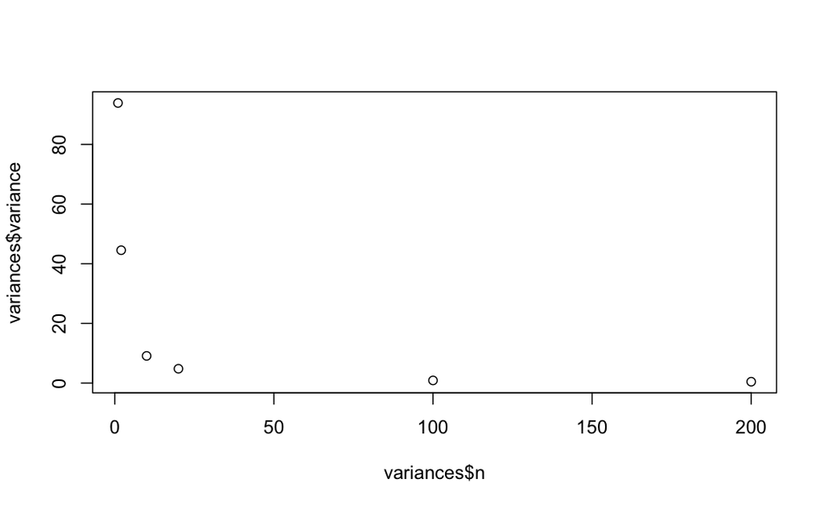

In addition to becoming narrower, the shape of X 𝑛’s distribution changes from being skewed to becoming symmetric and bell-shaped, like the normal distribution, as 𝑛 becomes larger.

### QUANTILE-QUANTILE PLOTS

We can test how close the distribution of X 𝑛 is to the normal distribution by examining quantile-quantile ( Q-Q ) plots. In a Q-Q plot, quantiles of the sample are plotted against quantiles of a proposed distribution, also known as theoretical quantiles.

[output not shown]

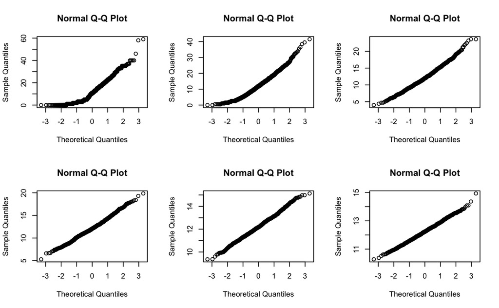

```r
par(mfrow=c(2,3))
mapply(\(m) qqnorm(mean.age(m)), means_variances)
```

If the points of a Q-Q plot fall on a straight line, this indicates that the sample data are consistent with the proposed distribution ( here, the normal distribution ). As 𝑛 increases, what changes in the Q-Q plots?

### SHAPIRO-WILK TEST

```r
par(mfrow=c(2,3))
mapply(\(m) shapiro.test(mean.age(m)), means_variances)
```

```
          [,1]                          [,2]
statistic 0.9246486                     0.9762707
p.value   5.775251e-22                  1.037707e-11
method    "Shapiro-Wilk normality test" "Shapiro-Wilk normality test"
data.name "mean.age(m)"                 "mean.age(m)"
          [,3]                          [,4]
statistic 0.9974104                     0.993987
p.value   0.1122103                     0.0004816875
method    "Shapiro-Wilk normality test" "Shapiro-Wilk normality test"
data.name "mean.age(m)"                 "mean.age(m)"
          [,5]                          [,6]
statistic 0.9982197                     0.9992945
p.value   0.3871204                     0.9775445
method    "Shapiro-Wilk normality test" "Shapiro-Wilk normality test"
data.name "mean.age(m)"                 "mean.age(m)"
```

### SAMPLING DISTRIBUTIONS

A statistic is a value computed from data. In our example, our statistic is the average number of ER visits.

Is a statistic a random variable? Recall that a random variable is a numeric value associated with the outcome of an experiment. It has a distribution, a mean ( expected value ), and a variance.

Because data constitute a random realization of an experiment, each time we run the experiment, we will get a different value for our statistic. So, in fact, it has a distribution, a mean ( expected value ), and a variance.

**In other words, as our sample size increases, any distribution—normal or not—will have a mean that tends to behave normally.**

### THE CENTRAL LIMIT THEOREM

In the field of statistics, it’s rarely possible to collect all of the data from an entire population. Instead, we can gather a subset of data from a population and then use statistics for that sample to draw conclusions about the population.

The 2 most common characteristics that we use to define a population are its mean and standard deviation. And when data comes from a normal distribution, we immediately have an idea of the data’s shape.

The mean tells us the center of that distribution. The standard deviation tells us the spread.

**The central limit theorem tells us that, no matter what the population distribution looks like, the distribution of the sample means will approach a normal distribution.**